# anchoredDistr: a Package for the Bayesian Inversion of Geostatistical Parameters with Multi-type and Multi-scale Data

The Method of Anchored Distributions (MAD) is a method for Bayesian inversion designed for inferring both local (e.g. point values) and global properties (e.g. mean and variogram parameters) of spatially heterogenous fields using multi-type and multi-scale data. Software implementations of MAD exist in C++ and C# to import data, execute an ensemble of forward model simulations, and perform basic post-processing of calculating likelihood and posterior distributions for a given application. This article describes the R package *anchoredDistr* that has been built to provide an R-based environment for this method. In particular, *anchoredDistr* provides a range of post-processing capabilities for MAD software by taking advantage of the statistical capabilities and wide use of the R language. Two examples from stochastic hydrogeology are provided to highlight the features of the package for MAD applications in inferring anchored distributions of local parameters (e.g. point values of transmissivity) as well as global parameters (e.g. the mean of the spatial random function for hydraulic conductivity).

Heather Savoy (Civil and Environmental Engineering, University of California) , Falk Heße (Computational Hydrosystems, Helmholtz Centre for Environmental Research (UFZ)) , Yoram Rubin (Civil and Environmental Engineering, University of California)  
2017-06-28

## 1 Introduction

The field of geostatistics originated in the 1950s with the pioneering work of Krige (1951) and Matheron (1962) who tried to estimate the characteristics of subsurface properties with the limited measurements typically available in this field. This scarcity, caused by the high explorations costs, is exacerbated by the strong heterogeneity that many such subsurface properties exhibit. Both these factors combined make it impossible to describe any subsurface process with certainty, therefore necessitating the application of statistical tools. Today, geostatistics is used in many fields of earth science such as geology (Hohn 1962), hydrogeology (Kitanidis 2008), plus hydrology and soil science (Goovaerts 1999). To meet this demand, many software packages have been developed that provide practitioners and scientists alike with the much needed tools to apply geostatistics. In R, the best collection of such tools is arguably found in the [*gstat*](https://CRAN.R-project.org/package=gstat) package (Pebesma 2004) developed and maintained by Pebesma and colleagues. With *gstat*, it is possible to estimate (Kriging) and simulate (Gaussian process generation) heterogenous fields in one, two or three dimensions, therefore providing necessary tools for geostatistical analysis.

Any such statistical analysis should draw on all available data that are connected to the variable of interest to infer, i.e. to learn about, its spatial distribution as much as possible. Examples for such spatially distributed variables in earth sciences would be, e.g. the hydraulic conductivity of an aquifer, evapotranspiration rates of different land surface areas, and soil moisture. In classical statistics, such information may consist of measurements of the variable itself or so-called local variables. Here, local means that a point-by-point relationship between both variables exists. However, many data are non-local, which means they are connected to the variable of interest via a complicated forward model. For instance, hydraulic conductivity may be connected by a solute transport model to break-through curves of said solutes and soil moisture may be connected by a hydraulic catchment model to river discharge. To learn about the input from the output of such forward models means to invert them, hence the name inversion for such techniques.

The Method of Anchored Distributions (MAD) provides a Bayesian framework for the geostatistical inversion of spatially heterogeneous variables. MAD solves the aforementioned problem by converting non-local data into equivalent local data using the tools of Bayesian inference. The result of such a conversion is the consistent representation of all data (local and non-local) as local data only, which is then amendable to further geostatistical analysis (Rubin et al. 2010). So far, applications of MAD have been focused on hydrogeology (Murakami et al. 2010; Chen et al. 2012; Heße et al. 2015) as well as soil science (Over et al. 2015). However, given the explanations above, MAD is in no way limited to these fields and can be employed wherever non-local data need to be incorporated into a geostatistical framework. This generality also extends to the spatial model being inferred. While there are R packages utilizing Bayesian inference for spatial models such as [*spBayes*](https://CRAN.R-project.org/package=spBayes) (Finley et al. 2015), [*spTimer*](https://CRAN.R-project.org/package=spTimer) (Bakar and Sahu 2015), and *INLA* (Lindgren and HåRue 2015 software available from http://www.r-inla.org/), these packages have several constraints compared to *anchoredDistr*. First, each method assumes a Gaussian process for the spatial variability. MAD has no inherent distributional assumptions, which allows its application to a wide variety of scenarios where, for example, Gaussian fields are not justified. In addition, these packages are either geared toward large data sets (*spBayes* and *spTimer*) or applied to only local data (*spBayes*, *spTimer*, and *INLA*) while MAD focuses on addressing uncertainty due to sparse data sets by incorporating non-local data. Finally, MAD employs a non-parameteric likelihood estimation, which allows for great flexibility, in particular for non-linear forward models. The presented R package [*anchoredDistr*](https://CRAN.R-project.org/package=anchoredDistr) provides an interface to the C# implementation of MAD. It allows post-processing of calculating likelihood and posterior distributions as well as visualization of the data.

## 2 The Method of Anchored Distributions

Equation (1) displays the general procedure of Bayesian inference where $\theta$ represents the parameters of the variable being inferred (e.g. hydraulic conductivity) and $z$ represents the data informing the inference:
$$\label{eq:bayes}
p \left( \theta | z \right) \propto p\left( \theta \right) p\left( z | \theta \right). \tag{1}$$

An important element of MAD is a strict classification of all data into local $z_a$ and non-local data $z_b$, with the latter being the target of inversion. MAD employs Bayesian inference in the realm of geostatistics by expanding the supported parameters into $\theta$ for global parameters (describing overall trend and spatial correlation) and $\vartheta$ for local parameters. Since MAD is a Bayesian scheme, these $\theta$ and $\vartheta$ both have probability distributions. As mentioned above, MAD turns non-local data into equivalent local data $\vartheta$ by inverting the forward model that connects both. The non-local data therefore become anchored in space, hence the name Method of Anchored Distributions. Equation (2) displays the general form of MAD:
$$\label{eq:mad}
p \left( \theta, \vartheta | z_a, z_b \right) \propto p\left( \theta \right) p\left( \vartheta | \theta, z_a \right) p\left( z_b | \theta, \vartheta, z_a \right). \tag{2}$$

Open-source software implementations for applying the entirety of MAD are available both with a graphical interface and a command-line interface to guide users through connecting their forward models and random field generators and to execute the ensemble of forward simulations (Osorio-Murillo et al. 2015). This software (available at http://mad.codeplex.com) was inspired by the claim that inverse modeling will be widely applied in hydrogeology only if user-friendly software tools are available (Carrera et al. 2005).

The package *anchoredDistr* described here focuses on extending the post-processing capabilities of MAD software, particularly the calculation of the likelihood distribution $p\left( z_b | \theta, \vartheta, z_a \right)$ and the posterior distribution $p\left( \theta, \vartheta | , z_b, z_a \right)$ after the ensemble of forward model simulations is already complete. The MAD# software has basic post-processing capabilities, but does not offer the degree of flexibility as R for the post-processing analysis. For example, when handling $z_b$ in the form of time series, dimension reduction techniques are necessary for calculating the likelihood values. By having the R package *anchoredDistr*, users have the support to attach whichever applicable technique for their data.

## 3 General workflow

In the current version of *anchoredDistr*, which only handles the post-processing of a MAD application, it is assumed that prior distributions of local and global parameters, $p\left(\vartheta | \theta, z_a \right)$ and $p\left(\theta\right)$ respectively, have already been defined and sampled and that forward model simulations based on those samples have been executed either within the MAD# software or by other means of batch execution. If the MAD# software is used, this data is stored by MAD# in databases (extensions .xresult for project metadata and .xdata for each sample). The package *anchoredDistr* primarily consists of methods for the S4 class "`MADproject`" that extract and analyze data from these databases, i.e. handling information regarding the samples from the prior distributions and the resulting ensemble of simulated $z_b$ data. If MAD# is not used, the information can be formatted into a "`MADproject`" manually. The usage of *anchoredDistr* will generally follow the workflow below (also see Figure 1):

1. Create `"MADproject"` object with `new()` function (passing slot information if manually filling data)
2. Read data from MAD# databases, if being used, into `"MADproject"` object with `readMAD()`
3. View the observations and realizations with `plotMAD()`
4. Apply any necessary dimension reduction techniques to $z_b$ with `reduceData()`
5. Test the convergence of the likelihood distribution with respect to the number of realizations with `testConvergence()` (return to MAD software to run additional realizations if unsatisfactory)
6. Calculate likelihood and posterior distributions with `calcLikelihood()` and `calcPosterior()`, respectively
7. View the posterior distribution with `plotMAD()`.

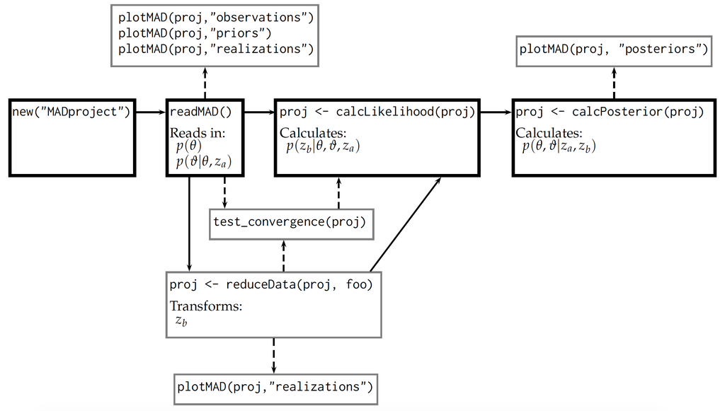

Figure 1: Schematic of utilizing *anchoredDistr* for MAD post-processing if the MAD# is used. Solid arrow lines indicate the fundamental workflow while dashed arrow lines are optional.

To install the *anchoredDistr* package, the release version is available from CRAN:

```r
  install.packages("anchoredDistr")
  library(anchoredDistr)
```

Alternatively, the development version can be obtained by using the [*devtools*](https://CRAN.R-project.org/package=devtools) package (Wickham and Chang 2016) to download the necessary files from GitHub:

```r
  library(devtools)
  install_github("hsavoy/anchoredDistr")
  library(anchoredDistr)
```

Other packages used by *anchoredDistr* include [*RSQLite*](https://CRAN.R-project.org/package=RSQLite) (Wickham et al. 2014) for reading from MAD databases, [*np*](https://CRAN.R-project.org/package=np) (Hayfield and Racine 2008) for estimating non-parametric density distributions, [*plyr*](https://CRAN.R-project.org/package=plyr) (Wickham 2011) and [*dplyr*](https://CRAN.R-project.org/package=dplyr) (Wickham and Francois 2016) for efficient data manipulation, and [*ggplot2*](https://CRAN.R-project.org/package=ggplot2) (Wickham 2009) for plotting. The methods included in *anchoredDistr* are listed in Table 1 and two examples utilizing these methods are provided next.

Table 1: The methods for the `"MADproject"` S4 class provided by *anchoredDistr*.

| Method | Description |
| --- | --- |
| `readMAD()` | Reads data from databases generated by MAD software |
| `reduceData()` | Applies dimension reduction to $z_b$ time series |
| `testConvergence()` | Tests for convergence of likelihood values for |
|  | increasing number of realizations |
| `calcLikelihood()` | Calculates the likelihood values for the samples |
| `calcPosterior()` | Calculates the posterior values for the samples |
| `plotMAD()` | Plots the observations, realizations, reduced data, |
|  | and/or posteriors |

## 4 Example 1: aquifer characterization with steady-state hydraulic head from multiple wells

### 4.1 Scenario setup

In this first example, we will use the tutorial example available from the MAD website http://mad.codeplex.com. Within the *anchoredDistr* package, this tutorial example is available as MAD# databases, as well as a `"MADproject"` object accessed by `data(tutorial)`. The variable of interest is transmissivity $T$, an aquifer property that represents how much water can be transmitted horizontally through an aquifer. We will use the one-dimensional heterogenous field of the decimal log transform of $T$ (see Figure 2) as our baseline field from which we can generate virtual measurements and validate our resulting posterior distributions. The field was generated as a Gaussian process by the *gstat* package in R with a mean $\mu_{\log_{10} T}=-2$ and an exponential covariance function with a variance $\sigma^2_{\log_{10}T}=0.4$ and length scale $l_{\log_{10}T} =3$ m. Within the scope of this example, we assume these global parameter values to be known. Furthermore, we assume that we have local data in the form of measurements of $T$ at three different locations. In addition, non-local data are available in the form of head measurements (indication of water pressure) at the same locations. The forward model used to solve the groundwater flow equation and relate $T$ to head is the software MODFLOW-96 (Harbaugh and Mcdonald 1996), part of the open source MODFLOW series that is the industry standard for groundwater modeling. To convert the non-local data into equivalent local data of $T$, we will place four anchors at selected unmeasured locations. The number of anchors needs to be justified by the data content of the measurements such that the complexity of the model does not become disproportionate to the information available. The locations of these anchors reflect locations where there is no other local data available but there is non-local data nearby for conversion (see Yang et al. (2012) for more discussion on anchor placement). The locations of the measurements and anchors are depicted in Figure 2. The prior distributions for these anchors are based on simple kriging with the local data $z_a$ for conditioning and the known Gaussian process for the covariance function:
$$\label{eq:anchor_priors}
p\left( \vartheta_i | \theta, z_a \right) = \mathcal{N}\left( \mu=\hat{Z}\left( y_i \right), \sigma^2=Var\left( Z\left( y_i \right) - \hat{Z}\left( y_i \right) \right) \right) , \tag{3}$$
where $Z$ generally represents $\log_{10} T$, $y_i$ is the $y$-coordinate of the $i^{th}$ anchor, $\hat{Z}\left( y_i \right)$ is the kriging estimate at the $i^{th}$ anchor , and $Var\left( Z\left( y_i \right) - \hat{Z}\left( y_i \right) \right)$ is the kriging variance at the $i^{th}$ anchor. The goal of the example is to compare the posterior distributions of the four anchors resulting from the inversion to their prior distributions which will indicate the information gain from the inclusion of the non-local data $z_b$.

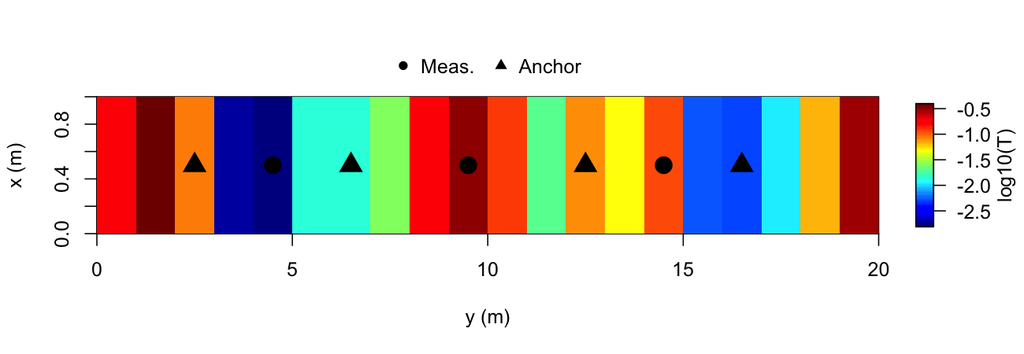

Figure 2: The one-dimensional baseline field of $\log_{10} T$ used in Example 1 with locations of measurements (co-located $z_a$ and $z_b$) marked along with the anchors to be inferred.

### 4.2 Reading and viewing data

In the first step, a `"MADproject"` object is created with the `new()` function. Three arguments must be provided to read the MAD databases: `madname` (the name of the MAD project, e.g. the filename for the .xmad database), `resultname` (the name of the result from MAD, e.g. the result folder name), and `xpath` (the path to where the .xresult database and result folder are located). These three arguments ensure the MAD databases can be read by the method `readMAD()`, which will read in the prior distribution samples for the global and local parameters plus the observations and forward model predictions for the $z_b$. Note that *anchoredDistr* could be used independently of the MAD software, if desired, as long as the slots filled in by `readMAD()` (see Table 2) are provided manually (see next example). To create a `"MADproject"` object for this tutorial example, the code below will read the MAD# databases stored in the *anchoredDistr* package files.

```r
  tutorial <- new("MADproject", madname="Tutorial", resultname="example1",
              xpath=paste0(system.file("extdata", package = "anchoredDistr"),"/"))
  tutorial <- readMAD(tutorial, 1:3)
```

Table 2: The slots for the `"MADproject"` S4 class provided by *anchoredDistr*.

| Slot | Description | Source |
| --- | --- | --- |
| `madname` | MAD project name | user provided |
| `resultname` | MAD result name | user provided |
| `xpath` | Path to .xresult database | user provided |
| `numLocations` | Number of $z_b$ locations | `readMAD()` |
| `numTimesteps` | Number of time steps measured at each $z_b$ locations | `readMAD()` |
| `numSamples` | Number of samples drawn from prior distributions | `readMAD()` |
| `numAnchors` | Number of local parameters / anchors placed in field | `readMAD()` |
| `numTheta` | Number of random global parameters to infer | `readMAD()` |
| `truevalues` | True values for the parameters to infer, if known | `readMAD()` |
| `observations` | Observed values of the $z_b$ locations and time steps | `readMAD()` |
| `realizations` | Simulated values of the $z_b$ locations and time steps | `readMAD()` |
| `priors` | Samples from the prior distributions of each parameter | `readMAD()` |
| `likelihoods` | Likelihood values for each sample | `calcLikelihoods()` |
| `posteriors` | Posterior values for each sample of each parameter | `calcPosteriors()` |

The prior distributions can be viewed by calling the `plotMAD()` function with the `"MADproject"` object and the string "priors" (see below). Figure 3 shows the prior distributions for the four anchors in Example 1. The distributions roughly follow a Gaussian distribution due to the baseline field being a Gaussian field and the prior distributions based on the kriging mean and variance at these four locations from the $z_a$ data and the known spatial random function. The x-axis labels are pulled from the `"MADproject"` object’s `priors` slot, which contains the random parameter names as provided in the MAD software.

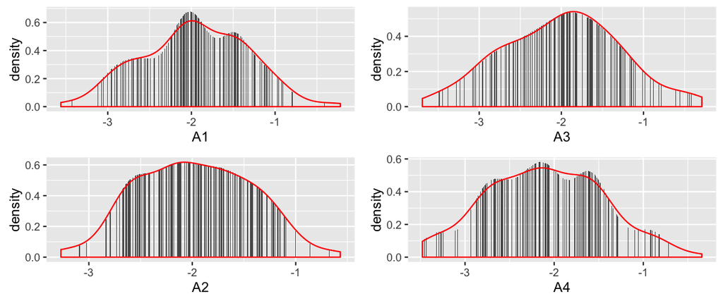

Figure 3: The relative frequency (gray bars) and estimated density (red line) of the prior distributions for the four anchor locations based on samples supplied in Example 1.

```r
  plotMAD(tutorial, "priors")
```

### 4.3 Calculating likelihoods and posteriors

After the information contained in the MAD databases has been read into the `"MADproject"` object, the likelihood and posterior distributions can be calculated by `calcLikelihood()` and `calcPosterior()`, respectively. The method `calcLikelihood()` uses non-parametric kernel density estimation (from the package *np*) to estimate the probability density of measured inversion data from the probability density function of inversion data simulated from the realizations per sample. The method `calcPosterior()` multiplies the resulting likelihood distribution across the samples and the provided prior distribution to calculate the posterior.

The posterior distributions for each random parameter can be seen by calling `plotMAD()` with the `"MADproject"` object and the string "posteriors". Figure 5 shows the posteriors for Example 1 along with the prior distribution and the true values for each of the four anchors. The posterior distributions for Anchors 2 and 3, which were surrounded by $z_b$ measurements, show an increase in probability near the true value, indicating a successful information transfer from the non-local $z_b$ into equivalent local data.

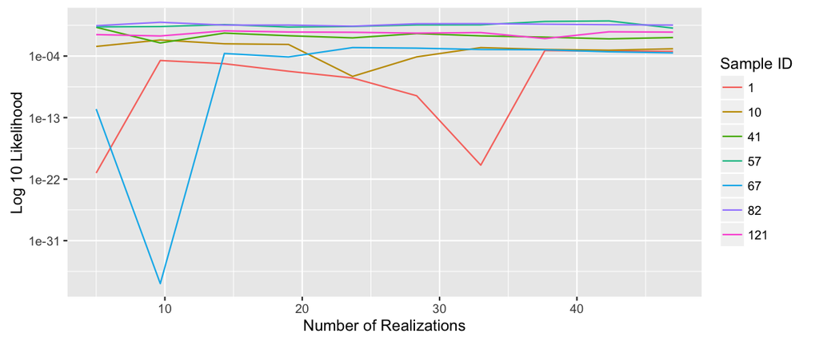

Figure 4: Convergence testing for Example 1 by plotting the decimal log of likelihood of a collection of randomly selected samples wth increasing number of realizations.

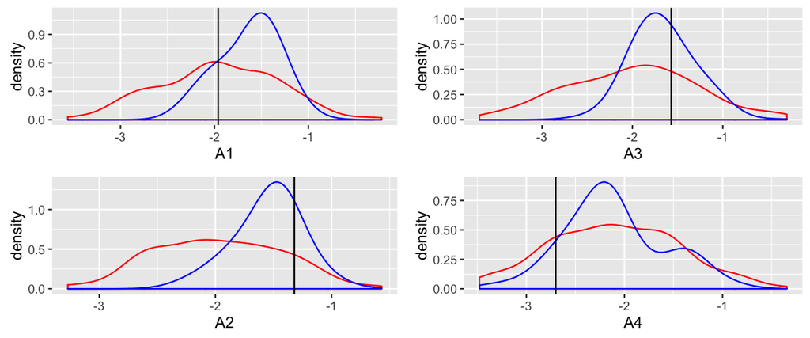

Figure 5: The prior (red) and posterior (blue) distributions with the true value (black) for the four anchor locations in Example 1.

```r
  testConvergence(tutorial)
  tutorial <- calcLikelihood(tutorial)
  tutorial <- calcPosterior(tutorial)
  plotMAD(tutorial, "posteriors")
```